# Naturalization of marriage migrants in Korea: origin paths around 2011

Consolidated report v2 · updated 28 October 2026 (controls, GLOBALCIT, Korean proficiency and tests) · National Multicultural Family Surveys 2015, 2018, 2021, 2024 · descriptive and associational; no causal effects identified

**Main findings**

- In absolute terms, only the Philippines and mainland China fell consistently after 2011 (duration-standardized rates down 4.5–7.1 points in all three surveys); Vietnamese, Korean Chinese and the other origins show no consistent change, and Taiwan’s rate rose on few events (Table 1B).
- Against 2005–08, the Philippines diverges from Vietnam and Taiwan after 2011 in both surveys and under every inference method (Table 2A), and also with sex, birth cohort and entry age controlled or among women only (Table 2E); against 2009–10 the evidence is weak.
- The Philippine relative decline matches mainland China's. Under GLOBALCIT's coding the Philippines has no loss rule since 2004, yet it falls even relative to origins that strip citizenship; the no-loss advantage rests on Vietnam alone (Tables 2B, 2D).
- Adding children (dated before the event), union end, household income and own employment leaves the 2011 contrasts and the Philippine decline nearly unchanged (Tables 2C, 3B, 3D). Most divorced respondents naturalized before the union ended.
- Later Philippine cohorts married more like Vietnamese cohorts (larger age gaps, more agency matches) yet naturalized far less; observed composition explains at most 18% of the decline, and at most 19% with all composition and family controls combined (Tables 4, 3A, 3D).
- Philippine non-naturalized respondents plan to naturalize less, largely through “don't know”; the gap narrows from −13 to −3 pp by 2024. Philippine naturalized respondents rarely report keeping Philippine nationality (Table 5).
- Lower Korean proficiency or the 2009–10 test and interview changes do not explain the pattern: Filipinas rate their Korean the same as Vietnamese women, mainland Chinese women rate it higher yet also fell, and controlling for proficiency leaves the 2011 contrasts and the Philippine decline nearly unchanged (Table 6).

## Table 1. Annual naturalization rates by period, observed and duration-standardized

### A. Rates

| Origin | Observed annual rate 2005–08 | Observed annual rate 2009–10 | Observed annual rate 2011–14 | Observed annual rate Δ 2011–14 − 2005–08, pp | Duration-standardized 2005–08 | Duration-standardized 2009–10 | Duration-standardized 2011–14 | Duration-standardized Δ 2011–14 − 2005–08, pp | Events |  |  |  |  |  |  |  |  |  |  |  |  |  |  |  |  |  |  |  |  | … |
| --- | --- | --- | --- | --- | --- | --- | --- | --- | --- | --- | --- | --- | --- | --- | --- | --- | --- | --- | --- | --- | --- | --- | --- | --- | --- | --- | --- | --- | --- | --- |
| 2015 survey |  |  |  |  |  |  |  |  |  |  |  |  |  |  |  |  |  |  |  |  |  |  |  |  |  |  |  |  |  | … |
| Philippines | 9.4% | 9.8% | 5.1% | -4.3 | 10.4% | 12.2% | 4.7% | -5.7 | 461 |  |  |  |  |  |  |  |  |  |  |  |  |  |  |  |  |  |  |  |  | … |
| Mainland China | 11.3% | 11.6% | 7.4% | -3.9 | 13.3% | 12.0% | 6.2% | -7.1 | 1,658 |  |  |  |  |  |  |  |  |  |  |  |  |  |  |  |  |  |  |  |  | … |
| Korean Chinese | 13.2% | 19.8% | 14.6% | +1.4 | 14.0% | 18.6% | 13.4% | -0.6 | 1,710 |  |  |  |  |  |  |  |  |  |  |  |  |  |  |  |  |  |  |  |  | … |
| Vietnam | 3.7% | 9.0% | 10.6% | +7.0 | 6.1% | 10.0% | 8.0% | +1.9 | 1,175 |  |  |  |  |  |  |  |  |  |  |  |  |  |  |  |  |  |  |  |  | … |
| Taiwan | 3.2% | 4.0% | 6.4% | +3.3 | 3.3% | 3.8% | 6.9% | +3.6 | 127 |  |  |  |  |  |  |  |  |  |  |  |  |  |  |  |  |  |  |  |  | … |
| Japan | 0.3% | 0.7% | 0.2% | -0.1 | 0.3% | 0.6% | 0.2% | -0.1 | 44 |  |  |  |  |  |  |  |  |  |  |  |  |  |  |  |  |  |  |  |  | … |
| Thailand | 2.0% | 3.3% | 2.9% | +0.9 | 2.1% | 3.1% | 2.3% | +0.2 | 95 |  |  |  |  |  |  |  |  |  |  |  |  |  |  |  |  |  |  |  |  | … |
| Mongolia | 4.8% | 5.2% | 5.5% | +0.7 | 6.2% | 4.9% | 4.4% | -1.8 | 152 |  |  |  |  |  |  |  |  |  |  |  |  |  |  |  |  |  |  |  |  | … |
| Cambodia | 1.6% | 4.6% | 8.9% | +7.3 | 6.5% | 5.7% | 3.9% | -2.5 | 279 |  |  |  |  |  |  |  |  |  |  |  |  |  |  |  |  |  |  |  |  | … |
| 2021 survey |  |  |  |  |  |  |  |  |  |  |  |  |  |  |  |  |  |  |  |  |  |  |  |  |  |  |  |  |  | … |
| Philippines | 9.7% | 6.6% | 4.1% | -5.7 | 9.4% | 7.0% | 3.9% | -5.5 | 367 |  |  |  |  |  |  |  |  |  |  |  |  |  |  |  |  |  |  |  |  | … |
| Mainland China | 9.4% | 10.1% | 6.1% | -3.2 | 10.6% | 10.3% | 5.7% | -5.0 | 916 |  |  |  |  |  |  |  |  |  |  |  |  |  |  |  |  |  |  |  |  | … |
| Korean Chinese | 9.4% | 14.9% | 8.6% | -0.7 | 9.6% | 14.2% | 8.6% | -1.0 | 1,173 |  |  |  |  |  |  |  |  |  |  |  |  |  |  |  |  |  |  |  |  | … |
| Vietnam | 4.0% | 8.7% | 8.2% | +4.2 | 5.6% | 9.1% | 6.8% | +1.2 | 862 |  |  |  |  |  |  |  |  |  |  |  |  |  |  |  |  |  |  |  |  | … |
| Taiwan | 1.4% | 4.7% | 4.5% | +3.1 | 1.5% | 5.0% | 4.7% | +3.2 | 85 |  |  |  |  |  |  |  |  |  |  |  |  |  |  |  |  |  |  |  |  | … |
| Japan | 0.3% | 0.5% | 0.2% | -0.1 | 0.5% | 0.4% | 0.2% | -0.3 | 20 |  |  |  |  |  |  |  |  |  |  |  |  |  |  |  |  |  |  |  |  | … |
| Thailand | 2.3% | 2.0% | 2.1% | -0.2 | 1.9% | 1.9% | 2.0% | +0.1 | 53 |  |  |  |  |  |  |  |  |  |  |  |  |  |  |  |  |  |  |  |  | … |
| Mongolia | 3.5% | 6.2% | 4.5% | +1.0 | 3.9% | 6.4% | 3.7% | -0.2 | 133 |  |  |  |  |  |  |  |  |  |  |  |  |  |  |  |  |  |  |  |  | … |
| Cambodia | 2.0% | 7.4% | 8.6% | +6.6 | 3.9% | 8.0% | 6.8% | +3.0 | 250 |  |  |  |  |  |  |  |  |  |  |  |  |  |  |  |  |  |  |  |  | … |

Annual rate = weighted naturalizations ÷ weighted person-years at risk, reconstructed retrospectively within each survey. Duration-standardized rates hold each origin's exact years-since-entry distribution fixed across the three periods. Δ = 2011–14 minus 2005–08. Events = naturalizations 2005–14. The nine origins used throughout the report; Hong Kong (26–46 respondents per survey) and the pooled ‘other foreign’ group are not shown (counts in Appendix A9). Japan, Thailand, Mongolia and Cambodia added 27 Oct 2026.

### B. Is the 2011–14 vs 2005–08 change statistically significant? Duration-standardized rates

| Origin | 2015 survey Δ pp | 2015 survey 95% CI, respondent bootstrap | 2015 survey p | 2015 survey OR, year clusters | 2015 survey CR2 p | 2015 survey Wild p | 2018 survey Δ pp | 2018 survey 95% CI, respondent bootstrap | 2018 survey p | 2018 survey OR, year clusters | 2018 survey CR2 p | 2018 survey Wild p | 2021 survey Δ pp | 2021 survey 95% CI, respondent bootstrap | 2021 survey p | 2021 survey OR, year clusters | 2021 survey CR2 p | 2021 survey Wild p |
| --- | --- | --- | --- | --- | --- | --- | --- | --- | --- | --- | --- | --- | --- | --- | --- | --- | --- | --- |
| Philippines | -5.7 | -7.5 to -4.0 | <.001 | 0.42 | .009 | .007 | -4.5 | -7.2 to -2.0 | <.001 | 0.51 | .093 | .094 | -5.5 | -7.5 to -3.6 | <.001 | 0.36 | .014 | .011 |
| Mainland China | -7.1 | -8.3 to -6.1 | <.001 | 0.44 | .002 | .002 | -5.2 | -7.1 to -3.1 | <.001 | 0.55 | .008 | .005 | -5.0 | -6.5 to -3.5 | <.001 | 0.51 | .003 | .002 |
| Korean Chinese | -0.6 | -2.3 to +0.9 | .472 | 0.99 | .918 | .908 | -2.5 | -4.3 to -0.8 | .006 | 0.78 | .241 | .216 | -1.0 | -2.7 to +0.5 | .202 | 0.88 | .462 | .392 |
| Vietnam | +1.9 | +0.5 to +3.2 | .008 | 1.22 | .197 | .210 | -0.9 | -3.2 to +1.3 | .436 | 0.92 | .720 | .695 | +1.2 | -0.5 to +2.7 | .172 | 1.13 | .412 | .289 |
| Taiwan | +3.6 | +1.6 to +5.5 | <.001 | 2.12 | .022 | .017 | +1.3 | -0.4 to +3.7 | .122 | 1.45 | .502 | .419 | +3.2 | +1.5 to +5.0 | <.001 | 3.43 | .011 | .003 |
| Japan | -0.1 | -0.3 to +0.1 | .500 | 0.66 | .381 | .427 | -0.5 | -1.6 to +0.7 | .396 | 0.76 | .463 | .472 | -0.3 | -0.9 to +0.2 | .400 | 0.65 | .560 | .711 |
| Thailand | +0.2 | -1.1 to +1.5 | .770 | 0.95 | .875 | .861 | -2.8 | -5.0 to -0.5 | .008 | 0.38 | .119 | .188 | +0.1 | -1.6 to +1.9 | .954 | 0.90 | .777 | .761 |
| Mongolia | -1.8 | -4.1 to +0.1 | .076 | 0.70 | .023 | .021 | -1.7 | -5.9 to +2.2 | .516 | 0.80 | .626 | .586 | -0.2 | -2.4 to +1.5 | .760 | 0.86 | .604 | .565 |
| Cambodia | -2.5 | -8.8 to +1.7 | .292 | 0.83 | .696 | .664 | -1.2 | -8.5 to +3.1 | .574 | 0.85 | .827 | .822 | +3.0 | -0.3 to +5.3 | .074 | 1.73 | .205 | .059 |

Δ = duration-standardized annual rate 2011–14 minus 2005–08, percentage points (the Table 1A values, recomputed from the raw files and identical to them). Respondent bootstrap: 1,000 resamples of respondents, percentile interval; it reflects the sampling of people only. Year clusters: weighted logit of the annual naturalization event on period indicators (2011–14, 2009–10; reference 2005–08) and years-since-entry bands (0–2, 3–5, 6–9, 10–14, 15+), CR2 standard errors with the ten calendar years as clusters (Satterthwaite df) and a restricted wild score bootstrap (Webb weights, 9,999 draws); it also reflects year-to-year shocks common to all respondents, as in Table 2. OR = odds ratio for 2011–14 vs 2005–08. For Thailand in the 2018 survey the finer bands did not converge and bands 0–2, 3–5, 6+ are used. Source: 58_standardized_change_tests.py.

**Key takeaways**

- **Only the Philippines and mainland China fell consistently.** Their duration-standardized annual rates dropped by 4.5–7.1 points, from 9–13% in 2005–08 to 4–6% in 2011–14, in all three surveys; the falls are significant with year clusters in 5 of 6 estimates (exception: Philippines in the 2018 survey, p = .093).
- **No consistent change elsewhere.** For Korean Chinese, Vietnam, Japan, Thailand, Mongolia, Cambodia the standardized change lies between -2.8 and +3.0 pp; the only significant estimate among them is Mongolia in the 2015 survey (-1.8 pp, p = .023), not repeated in the other surveys. Vietnam's Δ is +1.9, -0.9, +1.2 pp (year-cluster p = .197, .720, .412); its 2015 increase is significant only in the respondent bootstrap and comes from long durations (six years or more), where few Vietnamese were at risk in 2005–08.
- **Taiwan rose** (Δ +3.6, +1.3, +3.2 pp; year-cluster p = .022, .502, .011), but on only 85–127 events per survey.
- **Standardization matters for Vietnam.** Its observed rate rose by +7.0 and +4.2 points (2015, 2021 surveys) because many Vietnamese arrived after 2005 and reached peak naturalization durations after 2011; holding the years-since-entry distribution fixed removes most of that rise.

## Table 2. Relative change in naturalization odds after 2011, by origin

### A. Pairwise contrasts among the three origins

| Contrast | 2015 survey Ratio of ORs | 2015 survey CR2 p | 2015 survey Wild bootstrap p | 2021 survey Ratio of ORs | 2021 survey CR2 p | 2021 survey Wild bootstrap p |  |  |  |  |  |  |  |  |  |  |  |  |  |  |  |  |  |  |  |  |  |  |  | … |
| --- | --- | --- | --- | --- | --- | --- | --- | --- | --- | --- | --- | --- | --- | --- | --- | --- | --- | --- | --- | --- | --- | --- | --- | --- | --- | --- | --- | --- | --- | --- |
| 2011–14 vs 2005–08 |  |  |  |  |  |  |  |  |  |  |  |  |  |  |  |  |  |  |  |  |  |  |  |  |  |  |  |  |  | … |
| Taiwan ÷ Philippines | 5.52 | .001 | .002 | 9.55 | .002 | .003 |  |  |  |  |  |  |  |  |  |  |  |  |  |  |  |  |  |  |  |  |  |  |  | … |
| Vietnam ÷ Philippines | 2.41 | .010 | .031 | 2.57 | .009 | .013 |  |  |  |  |  |  |  |  |  |  |  |  |  |  |  |  |  |  |  |  |  |  |  | … |
| Vietnam ÷ Taiwan | 0.44 | .020 | .004 | 0.27 | .007 | .002 |  |  |  |  |  |  |  |  |  |  |  |  |  |  |  |  |  |  |  |  |  |  |  | … |
| 2011–14 vs 2009–10 |  |  |  |  |  |  |  |  |  |  |  |  |  |  |  |  |  |  |  |  |  |  |  |  |  |  |  |  |  | … |
| Taiwan ÷ Philippines | 4.66 | .028 | .033 | 1.91 | .250 | .176 |  |  |  |  |  |  |  |  |  |  |  |  |  |  |  |  |  |  |  |  |  |  |  | … |
| Vietnam ÷ Philippines | 2.20 | .047 | .027 | 1.41 | .131 | .115 |  |  |  |  |  |  |  |  |  |  |  |  |  |  |  |  |  |  |  |  |  |  |  | … |
| Vietnam ÷ Taiwan | 0.47 | .055 | .065 | 0.74 | .460 | .480 |  |  |  |  |  |  |  |  |  |  |  |  |  |  |  |  |  |  |  |  |  |  |  | … |

Logit on collapsed cells: origin FE, calendar-year FE, natural-spline years since entry; origin×period interactions. Each entry is the ratio of two origins' period odds ratios, not a probability ratio. CR2 p: clubSandwich CR2/Satterthwaite with 10 calendar-year clusters (saved project estimates, reproduced exactly in point estimate). Wild bootstrap: restricted wild score bootstrap, Webb weights, 9,999 draws.

### B. Each origin relative to the average origin, 2011–14 vs 2005–08

| Origin | GLOBALCIT L05, 2005–14 | 2015 survey OR vs average | 2015 survey 95% CI | 2015 survey p | 2021 survey OR vs average | 2021 survey 95% CI | 2021 survey p |
| --- | --- | --- | --- | --- | --- | --- | --- |
| Taiwan | No loss | 2.55 | 1.64–3.97 | .002 | 3.86 | 1.56–9.57 | .013 |
| Vietnam | No loss (since 1989) | 1.86 | 1.28–2.72 | .008 | 1.53 | 1.13–2.08 | .015 |
| Cambodia | No loss (since 1997) | 1.70 | 0.37–7.87 | .216 | 2.58 | 0.88–7.62 | .065 |
| Thailand | Loss (withdrawal) | 1.83 | 0.64–5.23 | .203 | 1.14 | 0.58–2.23 | .645 |
| Mongolia | No loss | 1.00 | 0.62–1.61 | .988 | 1.19 | 0.65–2.19 | .491 |
| Japan | Loss (lapse) | 1.06 | 0.50–2.25 | .866 | 0.78 | 0.19–3.24 | .687 |
| Korean Chinese | Loss (PRC law) | 1.02 | 0.74–1.40 | .887 | 0.96 | 0.70–1.31 | .743 |
| Philippines | No loss for natural-born (since 2004, RA 9225 oath) | 0.55 | 0.37–0.81 | .010 | 0.45 | 0.25–0.79 | .013 |
| China | Loss (lapse) | 0.49 | 0.34–0.71 | .003 | 0.56 | 0.45–0.69 | <.001 |

Change in odds 2011–14 vs 2005–08 for each origin relative to the person-year-weighted average origin; same controls; CR2 year-cluster inference. Law column: GLOBALCIT Citizenship Law Dataset v3.1, L05 (loss of citizenship upon voluntary acquisition of a foreign citizenship), country-year values for 2005–14. **Correction to the 26 Sep version:** that version described the Philippines as ‘auto-loss’ (CA 63); since 2004 GLOBALCIT codes no loss for natural-born Filipinos (RA 9225), conditional on an oath of allegiance. Mongolia moves from ‘no retention’ to no loss and Thailand from ‘ambiguous’ to loss. Codes for every birth country in the surveys: Appendix A9.

### C. Robustness to added controls: children, union end, income, employment

| Specification | 2015 survey Taiwan ÷ Philippines | 2015 survey Vietnam ÷ Philippines | 2015 survey Joint p | 2021 survey Taiwan ÷ Philippines | 2021 survey Vietnam ÷ Philippines | 2021 survey Joint p |
| --- | --- | --- | --- | --- | --- | --- |
| Original specification | 5.52 (.001; .002) | 2.41 (.028; .024) | .012 | 9.55 (.002; .003) | 2.57 (.018; .011) | .016 |
| + child born by year t, union ended before t | 4.90 (.002; .002) | 2.31 (.029; .026) | .013 | 9.39 (.002; .003) | 2.33 (.021; .013) | .016 |
| + household income, own employment and wage (survey time) | 4.83 (.002; .002) | 2.34 (.029; .023) | .014 | 9.35 (.002; .003) | 2.33 (.022; .015) | .015 |

2011–14 vs 2005–08; ratio of odds ratios (CR2 p; wild bootstrap p). Same model as Table 2A with the listed controls added. Child and union-end indicators are time-varying and precede the event year; income and employment are measured at the survey. Against 2009–10 the joint test stays weak with controls (p = .168 in 2015, .516 in 2021).

### D. Origin groups by GLOBALCIT nationality law (L05)

| Origin groups by GLOBALCIT L05 | 2015 survey Ratio of ORs | 2015 survey p, year CR2 | 2015 survey p, origin CR2 | 2021 survey Ratio of ORs | 2021 survey p, year CR2 | 2021 survey p, origin CR2 |
| --- | --- | --- | --- | --- | --- | --- |
| No loss ÷ loss (9 origins) | 1.76 | .002 | .365 | 1.50 | .031 | .404 |
| … excluding Vietnam | 1.03 | .865 | .967 | 1.06 | .744 | .937 |
| … excluding China | 1.33 | .069 | .538 | 1.28 | .192 | .547 |
| … excluding the Philippines | 2.35 | .001 | .121 | 2.08 | .009 | .139 |
| No loss excl. Philippines ÷ loss | 2.33 | .001 | .124 | 2.06 | .009 | .142 |
| Philippines ÷ loss | 0.71 | .153 | .536 | 0.55 | .026 | .254 |

Groups: no loss = Philippines, Vietnam, Taiwan, Mongolia, Cambodia; loss = China, Korean Chinese, Japan, Thailand. 2011–14 vs 2005–08. Origin CR2 uses 9 origin clusters (8 when one is excluded). The no-loss advantage disappears without Vietnam and is never significant at the origin level; the Philippines falls relative to loss origins despite having no loss rule.

### E. Robustness: sex, birth cohort and entry age; women only

| Specification | 2015 survey Taiwan ÷ Philippines | 2015 survey Vietnam ÷ Philippines | 2015 survey Vietnam ÷ Taiwan | 2021 survey Taiwan ÷ Philippines | 2021 survey Vietnam ÷ Philippines | 2021 survey Vietnam ÷ Taiwan |
| --- | --- | --- | --- | --- | --- | --- |
| Original (Table 2A) | 5.52 (.001; .002) | 2.41 (.028; .031) | 0.44 (.023; .004) | 9.55 (.002; .003) | 2.57 (.018; .013) | 0.27 (.009; .002) |
| + sex | 5.27 (.001; .002) | 2.36 (.029; .034) | 0.45 (.026; .006) | 8.70 (.003; .003) | 2.61 (.017; .013) | 0.30 (.012; .002) |
| + sex, birth cohort, entry age | 5.97 (.002; .003) | 2.68 (.020; .017) | 0.45 (.039; .013) | 8.81 (.003; .004) | 2.79 (.011; .011) | 0.32 (.019; .007) |
| Women only | 2.74 (.017; .015) | 2.40 (.030; .036) | 0.88 (.733; .693) | 5.30 (.013; .010) | 2.69 (.013; .012) | 0.51 (.191; .151) |
| Women only + birth cohort, entry age | 3.10 (.020; .022) | 2.77 (.019; .015) | 0.89 (.782; .753) | 5.18 (.012; .011) | 2.83 (.008; .011) | 0.55 (.245; .202) |

2011–14 vs 2005–08; ratio of odds ratios (CR2 p; wild bootstrap p), year clusters as in Table 2A. Sex, 5-year birth cohort (1950–94, ends pooled) and entry-age band (≤22, 23–26, 27–30, 31–35, 36+) enter as fixed effects. The Philippine and Vietnamese samples are about 98% women, the Taiwanese about half men (372 and 360 Taiwanese respondents at risk in 2005–14 in the 2015 and 2021 surveys). Restricting to women roughly halves the Taiwan contrast and removes the Vietnam–Taiwan difference; the Vietnam–Philippines contrast does not depend on these choices. CR2 p here comes from the project's own CR2 code; for the original model Table 2A reports the R clubSandwich p, which is smaller for Vietnam ÷ Philippines (2015: .010 vs .028; 2021: .009 vs .018). Source: 59_robustness_full_controls.py.

**Key takeaways**

- **Relative, not absolute.** Against 2005–08, Vietnam's odds of naturalizing changed 2.41 and 2.57 times as much as the Philippines' (2015, 2021 surveys) and Taiwan's 5.52 and 9.55 times; all four contrasts are significant (CR2 p ≤ .010). Against 2009–10 the evidence is weak in the 2021 survey (p = .131–.460).
- The divergence comes from the Philippines falling, not Vietnam rising (Table 1B). Relative to the average origin, the Philippines (OR 0.55, 0.45) and mainland China (0.49, 0.56) are the two origins that fell (Table 2B).
- The contrasts survive controls for children, union end, income and employment (Table 2C) and for sex, birth cohort and entry age (Table 2E). Among women only, Taiwan ÷ Philippines is about half as large (2.74, 5.30) because Taiwan's sample is half men; Vietnam ÷ Philippines does not change.
- Origin nationality law does not explain the pattern: without Vietnam the no-loss advantage vanishes (1.03–1.06), it is never significant with origin clusters, and the Philippines falls even relative to loss origins (0.55–0.71) despite having no loss rule (Table 2D).

## Figure 1. Year-by-year divergence from the Philippines

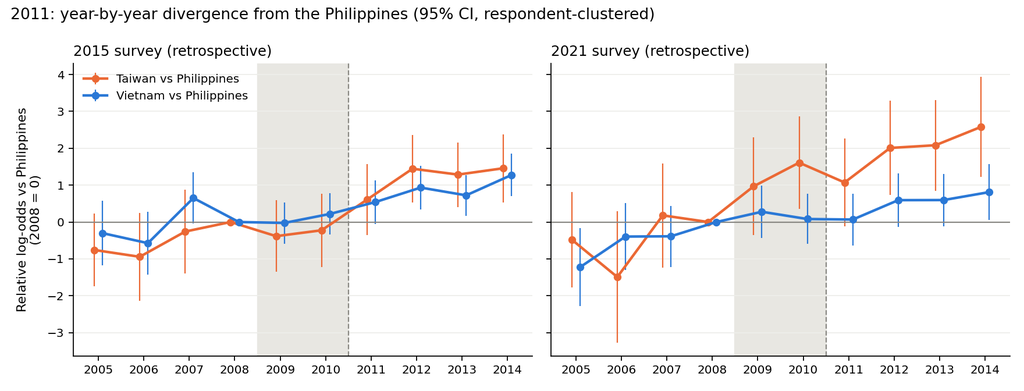

Origin×year interactions, reference 2008; shaded 2009–10 transition. Respondent-clustered 95% intervals ignore common year shocks. In the 2015 survey Vietnam's 2005–07 coefficients are jointly non-zero (p = .033).

**Key takeaways**

- Taiwan and Vietnam rise relative to the Philippines after 2010 in both surveys (Taiwan already in 2009–10 in the 2021 survey); before 2009 the paths are similar, except that Vietnam's 2005–07 coefficients in the 2015 survey are jointly non-zero (p = .033).
- Intervals are respondent-clustered and therefore too narrow; Table 2 gives the year-clustered tests.

## Figure 2. Cumulative naturalization by entry cohort, 2021 survey

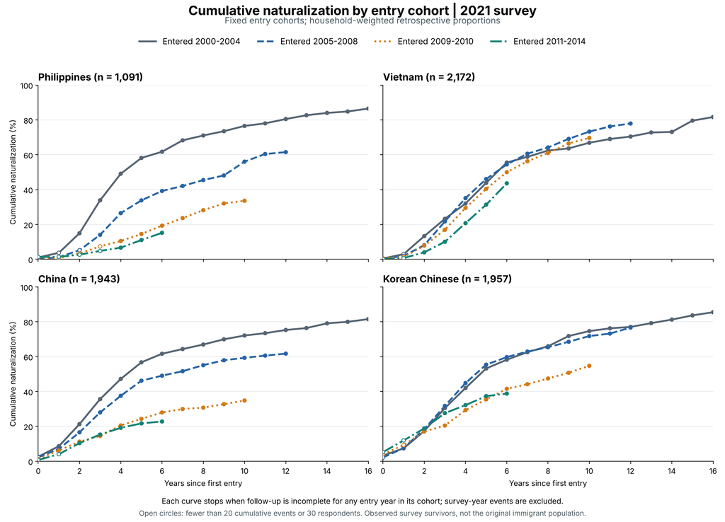

All respondents born in each origin (both sexes), household weights. Mainland China and Korean Chinese added 26 Oct 2026 (57_entry_cohort_cumulative_4origins.py); the Philippine and Vietnamese curves are identical to the earlier two-panel version. Panel titles give unweighted respondents in the four cohorts.

**Key takeaways**

- Naturalization within five years drops sharply from the 2005–08 to the 2009–10 entry cohort for the Philippines (34% → 15%), mainland China (46% → 24%) and Korean Chinese (55% → 35%), and much less for Vietnam (46% → 40%).
- Cohort and period overlap: migrants typically naturalize four to five years after entry, so the 2009–10 cohort reached those years only after 2011, while most people who naturalized in 2009–10 had entered in 2005–08. The curves cannot separate a cohort change from a post-2011 period change.

## Table 3. Does composition explain the Philippine decline? Naturalization within 5 years, stepwise controls

### A. Marriage and family composition (women with a co-resident spouse)

| Controls added cumulatively | 2015 survey (n=2,139; 2000-04→2009-10) Philippine decline, earliest → latest cohort | 2015 survey (n=2,139; 2000-04→2009-10) Philippines − Vietnam, latest cohort | 2018 survey (n=2,652; 2000-04→2011-14) Philippine decline, earliest → latest cohort | 2018 survey (n=2,652; 2000-04→2011-14) Philippines − Vietnam, latest cohort | 2021 survey (n=2,907; 2000-04→2011-14) Philippine decline, earliest → latest cohort | 2021 survey (n=2,907; 2000-04→2011-14) Philippines − Vietnam, latest cohort |
| --- | --- | --- | --- | --- | --- | --- |
| Cohort only | -40.2 (7.6) | -29.8 (7.6) | -49.4 (8.4) | -18.6 (7.8) | -47.2 (8.9) | -19.4 (8.4) |
| + entry age, first union, early cohabitation, meeting route | -41.7 (8.1) | -27.3 (7.7) | -51.7 (8.9) | -17.6 (7.8) | -45.4 (9.1) | -17.1 (8.3) |
| + husband's age gap and college, own schooling | -39.7 (8.2) | -28.7 (7.7) | -49.4 (9.0) | -19.1 (7.9) | -40.3 (8.9) | -19.0 (8.0) |
| + first child by entry+2, co-resident in-laws | -39.2 (8.3) | -28.0 (7.8) | -47.6 (9.0) | -18.9 (7.9) | -38.4 (8.9) | -18.6 (8.1) |
| + mother tongue, co-ethnic group, religious activity | -39.0 (8.3) | -29.2 (7.8) | -47.8 (9.0) | -18.6 (7.9) | -38.5 (8.9) | -18.6 (8.0) |

Percentage points; approximate SE in parentheses (HC1, combined as √(se₁²+se₂²)). Linear probability model of naturalization within 5 years of entry, women with a co-resident spouse, Philippines and Vietnam pooled, origin×cohort indicators. Missing covariates enter with indicator flags. Children, homeland ties and religious activity are measured at the survey and may follow naturalization.

### B. Children, marital status and income (all women)

| Controls added cumulatively | 2015 survey (n=2,309; 2000-04→2009-10) Philippine decline | 2015 survey (n=2,309; 2000-04→2009-10) Philippines − Vietnam, latest cohort | 2018 survey (n=2,901; 2000-04→2011-14) Philippine decline | 2018 survey (n=2,901; 2000-04→2011-14) Philippines − Vietnam, latest cohort | 2021 survey (n=3,208; 2000-04→2011-14) Philippine decline | 2021 survey (n=3,208; 2000-04→2011-14) Philippines − Vietnam, latest cohort |
| --- | --- | --- | --- | --- | --- | --- |
| Cohort only | -39.2 (7.3) | -29.0 (7.4) | -52.6 (9.3) | -15.9 (8.4) | -48.6 (8.7) | -20.9 (8.3) |
| + child born by year 5, union ended by year 5 | -40.4 (7.1) | -27.8 (7.3) | -53.5 (9.1) | -15.8 (8.3) | -47.7 (8.5) | -19.7 (8.1) |
| + current marital status | -39.5 (7.1) | -27.6 (7.3) | -51.5 (9.2) | -15.4 (8.5) | -44.9 (8.2) | -19.3 (7.7) |
| + household income (survey time) | -39.3 (7.2) | -27.2 (7.3) | -51.4 (9.3) | -14.8 (8.6) | -45.0 (8.1) | -19.7 (7.7) |
| + own employment and wage (survey time) | -37.6 (7.2) | -26.8 (7.3) | -51.3 (9.3) | -15.1 (8.6) | -44.6 (8.1) | -19.5 (7.7) |

Percentage points (approximate SE). All women from the Philippines and Vietnam, including divorced and widowed respondents (Table 3A is limited to women with a co-resident spouse). Child and union-end indicators are dated to year 5 after entry; current marital status, income and employment are measured at the survey. Reference categories: married, household income KRW 2–3m/month, not employed.

### C. Children and union end as time-varying predictors

|  | 2015 | 2018 | 2021 |  |  |  |  |  |  |  |  |  |  |  |  |  |  |  |  |  |  |  |  |  |  |  |  |  |  | … |
| --- | --- | --- | --- | --- | --- | --- | --- | --- | --- | --- | --- | --- | --- | --- | --- | --- | --- | --- | --- | --- | --- | --- | --- | --- | --- | --- | --- | --- | --- | --- |
| First child born by year t |  |  |  |  |  |  |  |  |  |  |  |  |  |  |  |  |  |  |  |  |  |  |  |  |  |  |  |  |  | … |
| All nine origins | 1.82 (1.68–1.96) | 1.59 (1.44–1.76) | 1.69 (1.54–1.87) |  |  |  |  |  |  |  |  |  |  |  |  |  |  |  |  |  |  |  |  |  |  |  |  |  |  | … |
| Philippines | 1.94 (1.47–2.55) | 1.26 (0.88–1.79) | 1.73 (1.27–2.35) |  |  |  |  |  |  |  |  |  |  |  |  |  |  |  |  |  |  |  |  |  |  |  |  |  |  | … |
| Vietnam | 2.30 (1.86–2.84) | 1.82 (1.46–2.28) | 2.29 (1.81–2.90) |  |  |  |  |  |  |  |  |  |  |  |  |  |  |  |  |  |  |  |  |  |  |  |  |  |  | … |
| Union ended before year t |  |  |  |  |  |  |  |  |  |  |  |  |  |  |  |  |  |  |  |  |  |  |  |  |  |  |  |  |  | … |
| All nine origins | 2.35 (1.77–3.12) | 0.85 (0.68–1.07) | 1.41 (1.09–1.81) |  |  |  |  |  |  |  |  |  |  |  |  |  |  |  |  |  |  |  |  |  |  |  |  |  |  | … |
| Philippines | 0.40 (0.06–2.74) | 0.23 (0.08–0.67) | 0.82 (0.30–2.19) |  |  |  |  |  |  |  |  |  |  |  |  |  |  |  |  |  |  |  |  |  |  |  |  |  |  | … |
| Vietnam | 1.17 (0.57–2.40) | 0.20 (0.07–0.53) | 0.88 (0.43–1.83) |  |  |  |  |  |  |  |  |  |  |  |  |  |  |  |  |  |  |  |  |  |  |  |  |  |  | … |

Discrete-time logit on person-years 2005–2014/2017, women; year FE, origin FE, duration spline, survey-time household income and own employment/wage; odds ratios with respondent-clustered 95% CI. Union end is dated only for widowhood in 2015 and for widowhood and divorce in 2018/2021; undated ended unions are flagged, never imputed. Post-dissolution exposure is small (about 85 person-years for the Philippines).

### D. All composition and family controls combined (women with a co-resident spouse)

| Controls | 2015 survey (n=2,139; 2000-04→2009-10) Philippine decline | 2015 survey (n=2,139; 2000-04→2009-10) Philippines − Vietnam, latest cohort | 2018 survey (n=2,652; 2000-04→2011-14) Philippine decline | 2018 survey (n=2,652; 2000-04→2011-14) Philippines − Vietnam, latest cohort | 2021 survey (n=2,907; 2000-04→2011-14) Philippine decline | 2021 survey (n=2,907; 2000-04→2011-14) Philippines − Vietnam, latest cohort |
| --- | --- | --- | --- | --- | --- | --- |
| Cohort only | -40.2 (7.6) | -29.8 (7.6) | -49.4 (8.4) | -18.6 (7.8) | -47.2 (8.9) | -19.4 (8.4) |
| Table 3A controls (all four steps) | -39.0 (8.3) | -29.2 (7.8) | -47.8 (9.0) | -18.6 (7.9) | -38.5 (8.9) | -18.6 (8.0) |
| Table 3B controls (child and union end by year 5, marital status, income, employment) | -39.4 (7.4) | -27.4 (7.6) | -48.4 (8.5) | -17.8 (7.9) | -45.4 (8.5) | -18.3 (7.9) |
| Table 3A and 3B controls combined | -36.6 (8.3) | -28.2 (7.9) | -47.0 (9.1) | -18.4 (8.1) | -38.1 (9.1) | -18.2 (8.2) |

Percentage points (approximate SE). Same linear probability model and sample as Table 3A (women with a co-resident spouse), adding the Table 3B covariates. Missing covariates enter with indicator flags; reference categories as in Table 3B. Source: 59_robustness_full_controls.py.

**Notes on the added controls**

- **Income.** Simplified naturalization requires financial self-sufficiency, so household monthly income (four bands) and own employment and wage (four groups) were added. Both are measured at the survey, usually after naturalization, and can be consequences of it; they are robustness controls, not pre-naturalization measures. Household income is barely associated with naturalization within origin and years in Korea; own employment and wage show small and inconsistent associations (-2.5 to +4.2 pp across surveys, nine origins pooled).
- **Marital status.** Most currently divorced or separated respondents naturalized *before* the union ended (Table 6D, with its limits). Those who did not naturalize before divorce are likely to have lost their status and left Korea, so current divorce partly reflects naturalization rather than causing it. The main specifications therefore use the dated ‘union ended before year t’ indicator; current marital status enters only as a sensitivity step.
- **Children.** Co-resident children's ages give each child's birth year, so ‘child born by year t’ precedes the outcome. Births are strongly associated with naturalization (odds ratio 1.3–2.3; the least precise estimate is Philippines, 2018 survey: 1.26, 95% CI 0.88–1.79), more so for Vietnamese than Filipino women, but the share with a child within five years of entry is similar for the two origins and did not fall in later Philippine cohorts, so children do not explain the Philippine decline. Children living elsewhere are not observed.
- **Result.** The 2011 origin contrasts (Table 2C) and the Philippine cohort decline (Table 3B) change little with these controls.

**Key takeaways**

- Among women with a co-resident spouse, Philippine naturalization within five years fell by 40–49 points from the earliest to the latest entry cohort; the latest Philippine cohort is 19–30 points below Vietnam's.
- Observed composition explains little of this: at most 18% with marriage, family and homeland-tie controls (Table 3A) and at most 19% with all composition and family controls combined (Table 3D).
- Births are associated with naturalization (odds ratio 1.3–2.3), but early childbearing is about as common among Filipino as among Vietnamese women and changed little across Philippine cohorts; most currently divorced women naturalized before the union ended (67–74% vs 10–14% after, 2018 and 2021 surveys), so neither explains the decline (Tables 3B–3C).

## Table 4. Entry-cohort profiles of Philippine and Vietnamese women

| Entry cohort | Philippines 2000-04 | Philippines 2005-08 | Philippines 2009-10 | Philippines 2011-14 | Vietnam 2000-04 | Vietnam 2005-08 | Vietnam 2009-10 | Vietnam 2011-14 |
| --- | --- | --- | --- | --- | --- | --- | --- | --- |
| Women, n | 316 | 244 | 179 | 330 | 139 | 834 | 449 | 717 |
| Naturalized within 5 years of entry | 59.8% | 35.3% | 15.0% | 11.2% | 44.0% | 46.8% | 40.7% | 32.1% |
| Entry age, mean | 26.6 | 24.8 | 25.4 | 25.5 | 21.0 | 21.9 | 22.8 | 23.8 |
| Years of schooling abroad, mean (member v6) | 11.9 | 11.7 | 11.6 | 11.9 | 9.6 | 9.4 | 9.7 | 10.0 |
| Husband's age minus own age, mean years | 8.7 | 12.6 | 13.0 | 14.4 | 14.6 | 15.8 | 15.7 | 17.3 |
| Met spouse through agency | 23.0% | 28.6% | 26.9% | 36.5% | 49.0% | 59.0% | 50.1% | 46.8% |
| Met spouse through religious organization | 35.2% | 3.9% | 5.2% | 1.2% | 0.0% | 0.2% | 0.5% | 0.1% |
| First marriage (current union) | 88.9% | 91.3% | 90.9% | 96.7% | 82.1% | 88.8% | 82.8% | 87.7% |
| First co-resident child born ≤2 years after entry | 60.3% | 61.2% | 56.3% | 57.5% | 47.2% | 67.5% | 63.4% | 61.8% |
| Widowed, divorced or separated now | 22.7% | 7.4% | 2.8% | 2.9% | 17.3% | 13.3% | 7.2% | 4.8% |
| Participates in religious activities | 33.7% | 33.4% | 25.2% | 19.4% | 8.5% | 14.0% | 10.2% | 9.9% |
| Post-secondary schooling (2015 survey, member v7) | 53.9% | 57.1% | 46.2% | 52.5% | 5.7% | 5.1% | 8.0% | 9.6% |

2021 survey unless stated; women; household weights; n is unweighted. The 5-year outcome includes entry year 0–5 and is defined only for cohorts whose year 5 precedes the survey. Spouse and route items refer to the current spouse. **Schooling:** in the 2018/2021 member files v7 records schooling *in Korea* (84–89% of immigrants ‘none’); schooling abroad is v6 (years), used here. Philippine basic education was 10 years before the 2012 K-12 reform, so equal years understate Philippine attainment.

**Key takeaways**

- Later Philippine cohorts look more like Vietnamese cohorts: the husband's age gap grew from 8.7 to 14.4 years (Vietnam 17.3), agency matches from 23% to 37% (Vietnam 47%), and religious-organization matches fell from 35% to 1%.
- Yet naturalization within five years fell from 60% to 11% for Philippine women, against 44% to 32% for Vietnamese women (2021 survey).
- Years of schooling abroad stayed about the same within each origin, so a change in education does not account for the decline.

## Table 5. Plans among the not yet naturalized, and nationality retained by the naturalized

### A. Plans to naturalize

| Survey | Plans to naturalize Philippines | Plans to naturalize Vietnam | Don't know Philippines | Don't know Vietnam | Philippines − Vietnam, pp (SE) Plans: years, age, sex | Philippines − Vietnam, pp (SE) Plans: all controls | Philippines − Vietnam, pp (SE) Don't know: all controls |
| --- | --- | --- | --- | --- | --- | --- | --- |
| 2015 | 70.6% | 85.4% | 13.8% | 6.9% | -13.3 (2.0) | -14.8 (2.4) | +8.2 (1.8) |
| 2018 | 78.1% | 89.9% | 13.9% | 5.4% | -11.3 (2.3) | -11.3 (2.5) | +9.3 (2.1) |
| 2021 | 71.5% | 81.1% | 19.5% | 14.4% | -7.1 (2.7) | -7.6 (2.9) | +3.8 (2.7) |
| 2024 | 70.0% | 77.6% | 19.3% | 13.6% | -3.0 (3.8) | — | — |

Non-naturalized respondents; personal weights. 2015 answer categories (Korean nationality / permanent residence only / neither / don't know) are mapped to plan / no plan / no plan / don't know. ‘All controls’ adds Korean proficiency, F-5 status, current marriage, schooling, husband's age gap and college, meeting route, children, co-resident in-laws and homeland-tie items. 2024: women only; years-in-Korea band and age.

### B. Naturalized respondents holding the birth-country nationality

| Origin | 2015 (reconstructed) | 2018 | 2021 | 2024 |
| --- | --- | --- | --- | --- |
| Philippines | 18.6 (15.6–21.6) | 9.2 (5.9–12.6) | 6.4 (4.2–8.6) | 8.7 (6.1–11.3) |
| Vietnam | 31.2 (28.6–33.8) | 16.7 (14.5–19.0) | 15.0 (13.1–16.8) | 15.7 (13.6–17.9) |
| China | 4.3 (3.5–5.2) | 0.9 (0.3–1.6) | 1.0 (0.3–1.7) | 3.4 (1.8–4.9) |
| Korean Chinese | 2.1 (1.5–2.7) | 2.2 (1.4–3.0) | 0.7 (0.1–1.2) | 1.6 (0.9–2.4) |

Share of naturalized respondents reporting the birth-country nationality as a current nationality, % (95% CI); personal weights. 2015 is reconstructed from a differently worded item and is not directly comparable. Source: dual_holding_waves_20260913.

**Key takeaways**

- Non-naturalized Filipinos are less likely than Vietnamese to plan to naturalize: -13, -11 and -7 points in the 2015, 2018 and 2021 surveys and -3 in 2024 (years in Korea, age and sex held fixed).
- The gap is largely uncertainty rather than refusal: Filipinos answer ‘don't know’ more often (14–19% vs 5–14%), and adding all controls leaves the gap about the same (-15, -11, -8).
- Naturalized Filipinos rarely keep Philippine nationality (6–9% in 2018–2024, against 15–17% of naturalized Vietnamese keeping Vietnamese nationality), although Philippine law has allowed natural-born citizens to keep it since 2004 (RA 9225).

## Table 6. Korean proficiency, naturalization tests and marriage

### A. Test and nationality rules for marriage migrants, 2007–2018

| Date | Change | Who it applies to |
| --- | --- | --- |
| Sep 2007 | Ministry of Justice announces that marriage applicants will lose the written-test exemption from 2009 | Announcement only: the published guidelines of 2008–10 kept the exemption for applicants married to a Korean citizen |
| 1 Jan 2009 | Completing the Korea Immigration and Integration Program (KIIP) exempts applicants from the written test | All applicants (alternative route) |
| Jun–Jul 2009 | Written test reformatted (20 multiple-choice items); retakes cut from two to one for applications from 1 Jul 2009 | Applicants who must sit the test |
| 2010 | Interview required also for marriage applicants previously exempt; at most two attempts; held at 17 immigration offices | All marriage applicants |
| 1 Jul 2010 | Written-test exemption kept for applicants still married; removed for those applying after divorce or widowhood or as parents of a Korean child; KIIP completers exempt from the interview | Married: exempt from written test. Divorced/widowed/parent route: test required |
| 1 Jan 2011 | Act No. 10275: renounce the foreign nationality within one year (was six months) or pledge not to exercise it in Korea; KIIP interview exemption written into the Decree and Ordinance | Pledge open only to those married to a Korean citizen at naturalization (Art. 6(2) items 1–2) |
| 1 Mar 2018 | Written test replaced by the KIIP naturalization comprehensive evaluation (multiple choice, writing, oral) | All applicants; after the 2005–14 analysis window |

Compiled from the project's legal review (docs/귀화제도개혁-2009-2011-2018-2019-통합정리-20260814.md), which checks each date against the law and guideline texts: [Ministry Ordinance 638](https://www.law.go.kr/LSW/lsInfoP.do?lsiSeq=86332), [Guideline 853](https://www.law.go.kr/LSW/admRulInfoP.do?admRulSeq=2000000007345), [Ministry of Justice 2010 interview notice](https://www.korea.kr/news/policyNewsView.do?newsId=148688073), [Guideline 936](https://www.law.go.kr/LSW/admRulInfoP.do?admRulSeq=2000000014086), [Act 10275](https://www.law.go.kr/LSW/nwRvsLsInfoR.do?lsKndCd=A0002&lsiSeq=104818). Before 2011 every naturalized person had to renounce the foreign nationality within six months or lose Korean nationality, whatever the origin country's law; the pre-2011 article text was confirmed from secondary sources, not retrieved directly.

### B. Self-rated Korean proficiency and TOPIK, women

| Origin | Self-rated Korean (1–5), by years since entry 0–2 | Self-rated Korean (1–5), by years since entry 3–5 | Self-rated Korean (1–5), by years since entry 6–9 | Self-rated Korean (1–5), by years since entry 10–14 | Self-rated Korean (1–5), by years since entry 15+ | Self-rated Korean (1–5), by years since entry All | TOPIK Ever taken | TOPIK Level 3+ among takers |  |  |  |  |  |  |  |  |  |  |  |  |  |  |  |  |  |  |  |  |  | … |
| --- | --- | --- | --- | --- | --- | --- | --- | --- | --- | --- | --- | --- | --- | --- | --- | --- | --- | --- | --- | --- | --- | --- | --- | --- | --- | --- | --- | --- | --- | --- |
| 2015 survey |  |  |  |  |  |  |  |  |  |  |  |  |  |  |  |  |  |  |  |  |  |  |  |  |  |  |  |  |  | … |
| Philippines | 2.88 | 3.09 | 3.35 | 3.33 | 3.38 | 3.24 | 26% | 41% |  |  |  |  |  |  |  |  |  |  |  |  |  |  |  |  |  |  |  |  |  | … |
| Mainland China | 2.96 | 3.37 | 3.68 | 4.27 | 4.47 | 3.93 | 20% | 60% |  |  |  |  |  |  |  |  |  |  |  |  |  |  |  |  |  |  |  |  |  | … |
| Korean Chinese | 3.90 | 4.24 | 4.32 | 4.50 | 4.56 | 4.46 | 10% | 42% |  |  |  |  |  |  |  |  |  |  |  |  |  |  |  |  |  |  |  |  |  | … |
| Vietnam | 2.82 | 3.15 | 3.34 | 3.44 | 3.41 | 3.22 | 23% | 44% |  |  |  |  |  |  |  |  |  |  |  |  |  |  |  |  |  |  |  |  |  | … |
| Taiwan | — | 3.20 | 3.76 | 3.93 | 4.66 | 4.17 | 14% | 77% |  |  |  |  |  |  |  |  |  |  |  |  |  |  |  |  |  |  |  |  |  | … |
| Japan | 2.71 | 3.16 | 3.54 | 3.58 | 3.81 | 3.61 | 32% | 91% |  |  |  |  |  |  |  |  |  |  |  |  |  |  |  |  |  |  |  |  |  | … |
| Thailand | 2.43 | 2.97 | 3.06 | 3.28 | 3.45 | 3.13 | 25% | 49% |  |  |  |  |  |  |  |  |  |  |  |  |  |  |  |  |  |  |  |  |  | … |
| Mongolia | — | 3.30 | 3.58 | 3.78 | 3.91 | 3.63 | 37% | 72% |  |  |  |  |  |  |  |  |  |  |  |  |  |  |  |  |  |  |  |  |  | … |
| Cambodia | 2.70 | 3.08 | 3.40 | — | — | 3.16 | 24% | 40% |  |  |  |  |  |  |  |  |  |  |  |  |  |  |  |  |  |  |  |  |  | … |
| 2018 survey |  |  |  |  |  |  |  |  |  |  |  |  |  |  |  |  |  |  |  |  |  |  |  |  |  |  |  |  |  | … |
| Philippines | 2.92 | 3.12 | 3.31 | 3.40 | 3.57 | 3.34 | 24% | 41% |  |  |  |  |  |  |  |  |  |  |  |  |  |  |  |  |  |  |  |  |  | … |
| Mainland China | 3.06 | 3.45 | 3.51 | 3.91 | 4.34 | 3.83 | 26% | 69% |  |  |  |  |  |  |  |  |  |  |  |  |  |  |  |  |  |  |  |  |  | … |
| Korean Chinese | — | 4.47 | 4.40 | 4.52 | 4.66 | 4.57 | 10% | 52% |  |  |  |  |  |  |  |  |  |  |  |  |  |  |  |  |  |  |  |  |  | … |
| Vietnam | 2.87 | 3.20 | 3.34 | 3.56 | 3.58 | 3.33 | 25% | 47% |  |  |  |  |  |  |  |  |  |  |  |  |  |  |  |  |  |  |  |  |  | … |
| Taiwan | — | 3.28 | 3.76 | 3.80 | 4.74 | 4.36 | 24% | 76% |  |  |  |  |  |  |  |  |  |  |  |  |  |  |  |  |  |  |  |  |  | … |
| Japan | 3.30 | 3.45 | 3.61 | 3.83 | 4.06 | 3.77 | 37% | 80% |  |  |  |  |  |  |  |  |  |  |  |  |  |  |  |  |  |  |  |  |  | … |
| Thailand | 2.52 | 2.96 | 3.18 | 3.38 | 3.53 | 3.15 | 24% | 50% |  |  |  |  |  |  |  |  |  |  |  |  |  |  |  |  |  |  |  |  |  | … |
| Mongolia | — | 3.53 | 3.60 | 3.88 | 3.99 | 3.83 | 32% | 81% |  |  |  |  |  |  |  |  |  |  |  |  |  |  |  |  |  |  |  |  |  | … |
| Cambodia | 2.92 | 3.15 | 3.36 | 3.53 | — | 3.32 | 31% | 37% |  |  |  |  |  |  |  |  |  |  |  |  |  |  |  |  |  |  |  |  |  | … |
| 2021 survey |  |  |  |  |  |  |  |  |  |  |  |  |  |  |  |  |  |  |  |  |  |  |  |  |  |  |  |  |  | … |
| Philippines | 2.62 | 3.08 | 3.24 | 3.45 | 3.49 | 3.32 | 23% | 56% |  |  |  |  |  |  |  |  |  |  |  |  |  |  |  |  |  |  |  |  |  | … |
| Mainland China | 3.03 | 3.33 | 3.61 | 3.93 | 4.35 | 4.01 | 24% | 74% |  |  |  |  |  |  |  |  |  |  |  |  |  |  |  |  |  |  |  |  |  | … |
| Korean Chinese | — | — | 4.41 | 4.48 | 4.60 | 4.55 | 15% | 58% |  |  |  |  |  |  |  |  |  |  |  |  |  |  |  |  |  |  |  |  |  | … |
| Vietnam | 2.84 | 3.11 | 3.32 | 3.50 | 3.59 | 3.32 | 24% | 48% |  |  |  |  |  |  |  |  |  |  |  |  |  |  |  |  |  |  |  |  |  | … |
| Taiwan | — | 3.36 | 3.67 | 4.31 | 4.69 | 4.14 | 27% | 73% |  |  |  |  |  |  |  |  |  |  |  |  |  |  |  |  |  |  |  |  |  | … |
| Japan | 3.08 | 3.45 | 3.75 | 3.85 | 3.97 | 3.78 | 36% | 85% |  |  |  |  |  |  |  |  |  |  |  |  |  |  |  |  |  |  |  |  |  | … |
| Thailand | 2.54 | 2.87 | 3.08 | 3.40 | 3.46 | 3.05 | 22% | 43% |  |  |  |  |  |  |  |  |  |  |  |  |  |  |  |  |  |  |  |  |  | … |
| Mongolia | — | 3.61 | 3.82 | 3.87 | 4.03 | 3.91 | 43% | 74% |  |  |  |  |  |  |  |  |  |  |  |  |  |  |  |  |  |  |  |  |  | … |
| Cambodia | 2.90 | 2.97 | 3.37 | 3.59 | 3.51 | 3.37 | 28% | 55% |  |  |  |  |  |  |  |  |  |  |  |  |  |  |  |  |  |  |  |  |  | … |

Women in the self-survey, personal weights. Korean is the mean of four self-ratings (speaking, listening, reading, writing), rescaled so 5 = very good and 1 = not at all; measured at the survey. TOPIK = Test of Proficiency in Korean (levels 1–6; level 3 is the usual intermediate threshold). “—” marks cells with fewer than 20 respondents. Source: 60_korean_language_tests.py (L1, L2).

### C. Does Korean proficiency explain the Philippine decline?

| Specification | Taiwan ÷ Philippines OR | Taiwan ÷ Philippines 95% CI | Taiwan ÷ Philippines CR2 p | Taiwan ÷ Philippines Wild p | Vietnam ÷ Philippines OR | Vietnam ÷ Philippines 95% CI | Vietnam ÷ Philippines CR2 p | Vietnam ÷ Philippines Wild p |  |  |  |  |  |  |  |  |  |  |  |  |  |  |  |  |  |  |  |  |  | … |
| --- | --- | --- | --- | --- | --- | --- | --- | --- | --- | --- | --- | --- | --- | --- | --- | --- | --- | --- | --- | --- | --- | --- | --- | --- | --- | --- | --- | --- | --- | --- |
| 2015 survey |  |  |  |  |  |  |  |  |  |  |  |  |  |  |  |  |  |  |  |  |  |  |  |  |  |  |  |  |  | … |
| Sample with Korean observed | 5.86 | 3.11–11.06 | <.001 | .002 | 2.45 | 1.16–5.16 | .027 | .028 |  |  |  |  |  |  |  |  |  |  |  |  |  |  |  |  |  |  |  |  |  | … |
| + Korean proficiency band FE | 6.03 | 3.14–11.58 | <.001 | .002 | 2.48 | 1.18–5.22 | .025 | .024 |  |  |  |  |  |  |  |  |  |  |  |  |  |  |  |  |  |  |  |  |  | … |
| Subgroup: Korean high (4+) | 5.00 | 2.12–11.80 | .004 | — | 3.05 | 2.04–4.56 | <.001 | — |  |  |  |  |  |  |  |  |  |  |  |  |  |  |  |  |  |  |  |  |  | … |
| Subgroup: Korean below 4 | 5.12 | 1.03–25.42 | .047 | — | 2.49 | 0.97–6.40 | .055 | — |  |  |  |  |  |  |  |  |  |  |  |  |  |  |  |  |  |  |  |  |  | … |
| 2021 survey |  |  |  |  |  |  |  |  |  |  |  |  |  |  |  |  |  |  |  |  |  |  |  |  |  |  |  |  |  | … |
| Sample with Korean observed | 9.47 | 3.40–26.40 | .002 | .003 | 2.57 | 1.27–5.19 | .018 | .013 |  |  |  |  |  |  |  |  |  |  |  |  |  |  |  |  |  |  |  |  |  | … |
| + Korean proficiency band FE | 9.74 | 3.51–27.01 | .002 | .003 | 2.58 | 1.28–5.18 | .017 | .014 |  |  |  |  |  |  |  |  |  |  |  |  |  |  |  |  |  |  |  |  |  | … |
| Subgroup: Korean high (4+) | 12.93 | 2.80–59.80 | .008 | — | 4.35 | 1.82–10.39 | .007 | — |  |  |  |  |  |  |  |  |  |  |  |  |  |  |  |  |  |  |  |  |  | … |
| Subgroup: Korean below 4 | — | — | — | — | — | — | — | — |  |  |  |  |  |  |  |  |  |  |  |  |  |  |  |  |  |  |  |  |  | … |

Table 2A model (year FE, origin FE, duration spline; 2011–14 vs 2005–08; calendar-year CR2 and restricted wild score bootstrap, 9,999 Webb draws), restricted to person-years with Korean observed (60_korean_language_tests.py, L3). Proficiency bands: below 2.5, 2.5–3.4, 3.5–4.4, 4.5 and above. Subgroup rows refit the model separately by proficiency (50_reestimation_new_specs.py, B4; no wild bootstrap); the 2021 low-proficiency subgroup was not reportable. Ratios above 1 mean the Philippines fell relative to the other origin.

| Specification | 2015 survey PH decline | 2015 survey PH − VN, last cohort | 2018 survey PH decline | 2018 survey PH − VN, last cohort | 2021 survey PH decline | 2021 survey PH − VN, last cohort |
| --- | --- | --- | --- | --- | --- | --- |
| Cohort only | -39.5 (7.3) | -29.5 (7.4) | -52.6 (9.4) | -15.2 (8.5) | -48.6 (8.7) | -20.9 (8.3) |
| + Korean proficiency | -38.4 (7.3) | -28.7 (7.4) | -50.0 (9.3) | -14.4 (8.4) | -46.6 (9.0) | -20.9 (8.6) |
| + Korean proficiency, child and union end by year 5 | -39.6 (7.2) | -27.5 (7.3) | -51.1 (9.1) | -14.3 (8.2) | -45.8 (8.8) | -19.8 (8.4) |

Percentage points (SE, HC1). Table 3B design: Philippine and Vietnamese women, naturalized within 5 years of entry, origin × entry cohort (2000–04 to 2009–10 in the 2015 survey, to 2011–14 in later surveys), restricted to Korean observed (60_korean_language_tests.py, L4). Each Korean point is associated with 7.2–9.0 pp higher 5-year naturalization.

### D. Did divorced and widowed women naturalize before the union ended?

| Survey · origin | n (dated end) | Before union ended | Same year | After union ended | Not naturalized |  |  |  |  |  |  |  |  |  |  |  |  |  |  |  |  |  |  |  |  |  |  |  |  | … |
| --- | --- | --- | --- | --- | --- | --- | --- | --- | --- | --- | --- | --- | --- | --- | --- | --- | --- | --- | --- | --- | --- | --- | --- | --- | --- | --- | --- | --- | --- | --- |
| Currently divorced or separated |  |  |  |  |  |  |  |  |  |  |  |  |  |  |  |  |  |  |  |  |  |  |  |  |  |  |  |  |  | … |
| 2018 · All nine origins | 845 | 67% | 8% | 10% | 15% |  |  |  |  |  |  |  |  |  |  |  |  |  |  |  |  |  |  |  |  |  |  |  |  | … |
| 2018 · Philippines | 54 | 71% | 3% | 4% | 21% |  |  |  |  |  |  |  |  |  |  |  |  |  |  |  |  |  |  |  |  |  |  |  |  | … |
| 2018 · Vietnam | 142 | 58% | 2% | 3% | 37% |  |  |  |  |  |  |  |  |  |  |  |  |  |  |  |  |  |  |  |  |  |  |  |  | … |
| 2018 · Mainland China | 158 | 67% | 10% | 8% | 14% |  |  |  |  |  |  |  |  |  |  |  |  |  |  |  |  |  |  |  |  |  |  |  |  | … |
| 2018 · Korean Chinese | 395 | 70% | 10% | 14% | 6% |  |  |  |  |  |  |  |  |  |  |  |  |  |  |  |  |  |  |  |  |  |  |  |  | … |
| 2021 · All nine origins | 821 | 74% | 5% | 14% | 7% |  |  |  |  |  |  |  |  |  |  |  |  |  |  |  |  |  |  |  |  |  |  |  |  | … |
| 2021 · Philippines | 82 | 81% | 1% | 7% | 11% |  |  |  |  |  |  |  |  |  |  |  |  |  |  |  |  |  |  |  |  |  |  |  |  | … |
| 2021 · Vietnam | 136 | 80% | 3% | 5% | 12% |  |  |  |  |  |  |  |  |  |  |  |  |  |  |  |  |  |  |  |  |  |  |  |  | … |
| 2021 · Mainland China | 196 | 76% | 4% | 10% | 10% |  |  |  |  |  |  |  |  |  |  |  |  |  |  |  |  |  |  |  |  |  |  |  |  | … |
| 2021 · Korean Chinese | 290 | 72% | 6% | 19% | 3% |  |  |  |  |  |  |  |  |  |  |  |  |  |  |  |  |  |  |  |  |  |  |  |  | … |
| Currently widowed |  |  |  |  |  |  |  |  |  |  |  |  |  |  |  |  |  |  |  |  |  |  |  |  |  |  |  |  |  | … |
| 2018 · All nine origins | 383 | 48% | 7% | 18% | 27% |  |  |  |  |  |  |  |  |  |  |  |  |  |  |  |  |  |  |  |  |  |  |  |  | … |
| 2018 · Philippines | 49 | 51% | 15% | 1% | 34% |  |  |  |  |  |  |  |  |  |  |  |  |  |  |  |  |  |  |  |  |  |  |  |  | … |
| 2018 · Vietnam | 45 | 34% | 5% | 5% | 55% |  |  |  |  |  |  |  |  |  |  |  |  |  |  |  |  |  |  |  |  |  |  |  |  | … |
| 2018 · Mainland China | 51 | 46% | 11% | 23% | 20% |  |  |  |  |  |  |  |  |  |  |  |  |  |  |  |  |  |  |  |  |  |  |  |  | … |
| 2018 · Korean Chinese | 182 | 58% | 5% | 24% | 13% |  |  |  |  |  |  |  |  |  |  |  |  |  |  |  |  |  |  |  |  |  |  |  |  | … |
| 2021 · All nine origins | 422 | 56% | 4% | 30% | 11% |  |  |  |  |  |  |  |  |  |  |  |  |  |  |  |  |  |  |  |  |  |  |  |  | … |
| 2021 · Philippines | 46 | 52% | 2% | 14% | 32% |  |  |  |  |  |  |  |  |  |  |  |  |  |  |  |  |  |  |  |  |  |  |  |  | … |
| 2021 · Vietnam | 65 | 58% | 5% | 14% | 23% |  |  |  |  |  |  |  |  |  |  |  |  |  |  |  |  |  |  |  |  |  |  |  |  | … |
| 2021 · Mainland China | 95 | 62% | 1% | 23% | 13% |  |  |  |  |  |  |  |  |  |  |  |  |  |  |  |  |  |  |  |  |  |  |  |  | … |
| 2021 · Korean Chinese | 147 | 56% | 4% | 38% | 2% |  |  |  |  |  |  |  |  |  |  |  |  |  |  |  |  |  |  |  |  |  |  |  |  | … |

Women; household weights; 54_income_marital_children.py (P2). Compares the naturalization year with the reported divorce or widowhood year; the 2015 survey does not date divorce. Limits: (1) years only, so the order within the same year is unknown; (2) the reported year is probably the legal divorce, so separation or proceedings that began earlier can make a naturalization look ‘before’; (3) migrants who divorced before naturalizing and then left Korea are not surveyed, which inflates the ‘before’ share; (4) remarried respondents are counted as married, not here.

**Key takeaways**

## Appendix

**A1. 2018–19: period contrasts, year effects and heterogeneity**

| Contrast | OR | 95% CI (independent CR2) | CR2 p (clubSandwich) | CR2 p (independent) | Wild bootstrap p |
| --- | --- | --- | --- | --- | --- |
| 2018 vs 2011–17 | 1.244 | 1.05–1.47 | .074 | .020 | .110 |
| 2019–20 vs 2011–17 | 1.327 | 1.01–1.74 | .055 | .046 | .020 |

2021 survey, 9,118 persons, 59,896 person-years, 3,839 events. Controls: origin, duration band, birth and entry cohorts. The two CR2 implementations disagree for this nearly singular model (condition number about 10<sup>14</sup>; Satterthwaite df 2.2 vs 4.9 for 2018); the text relies on the clubSandwich p.

| Year | 2011 | 2012 | 2013 | 2014 | 2015 | 2016 | 2017 | 2018 | 2019 | 2020 |
| --- | --- | --- | --- | --- | --- | --- | --- | --- | --- | --- |
| Log-odds vs 2017 | 0.38 | 0.13 | 0.03 | 0.04 | 0.12 | 0.10 | 0.00 | 0.27 | 0.30 | 0.33 |
| SE (respondent-clustered) | 0.13 | 0.13 | 0.12 | 0.12 | 0.11 | 0.11 | 0.00 | 0.11 | 0.10 | 0.11 |

Year fixed effects, reference 2017; respondent-clustered SEs ignore common year shocks and are too narrow.

| Subgroup | Gap before (OR) | Change in gap 2019–20 (OR) | 95% CI | CR2 p | Wild bootstrap p |
| --- | --- | --- | --- | --- | --- |
| Korean proficiency high vs low | 1.68 | 1.14 | 0.68–1.92 | .343 | .285 |
| Brokered vs not | 1.01 | 1.09 | 0.33–3.60 | .760 | .656 |
| ≥5 vs <5 years since entry | 1.28 | 1.18 | 0.50–2.83 | .585 | .678 |

**A2. 2011: alternative duration controls (2011–14 vs 2005–08)**

| Duration control | 2015 survey TW÷PH | 2015 survey VN÷PH | 2015 survey VN÷TW | 2021 survey TW÷PH | 2021 survey VN÷PH | 2021 survey VN÷TW |
| --- | --- | --- | --- | --- | --- | --- |
| Natural spline | 5.52 (.002) | 2.41 (.031) | 0.44 (.004) | 9.55 (.003) | 2.57 (.013) | 0.27 (.002) |
| Exact years-since-entry FE | 5.50 (.002) | 2.31 (.044) | 0.42 (.009) | 9.79 (.005) | 2.57 (.014) | 0.26 (.007) |
| Duration band × period FE | 2.45 (.044) | 3.86 (.002) | 1.58 (.147) | 4.53 (.010) | 3.78 (.007) | 0.83 (.727) |

Ratio of odds ratios (wild bootstrap p).

**A3. Observed annual rates within duration bands**

| Origin | 2005–08 | 2009–10 | 2011–14 |  |  |  |  |  |  |  |  |  |  |  |  |  |  |  |  |  |  |  |  |  |  |  |  |  |  | … |
| --- | --- | --- | --- | --- | --- | --- | --- | --- | --- | --- | --- | --- | --- | --- | --- | --- | --- | --- | --- | --- | --- | --- | --- | --- | --- | --- | --- | --- | --- | --- |
| 2-5 years since entry · 2015 survey |  |  |  |  |  |  |  |  |  |  |  |  |  |  |  |  |  |  |  |  |  |  |  |  |  |  |  |  |  | … |
| Mainland China | 19.5% | 16.3% | 8.7% |  |  |  |  |  |  |  |  |  |  |  |  |  |  |  |  |  |  |  |  |  |  |  |  |  |  | … |
| Korean Chinese | 20.3% | 24.3% | 15.4% |  |  |  |  |  |  |  |  |  |  |  |  |  |  |  |  |  |  |  |  |  |  |  |  |  |  | … |
| Taiwan | 4.3% | 11.5% | 4.1% |  |  |  |  |  |  |  |  |  |  |  |  |  |  |  |  |  |  |  |  |  |  |  |  |  |  | … |
| Philippines | 15.0% | 12.0% | 4.8% |  |  |  |  |  |  |  |  |  |  |  |  |  |  |  |  |  |  |  |  |  |  |  |  |  |  | … |
| Vietnam | 9.4% | 13.9% | 11.8% |  |  |  |  |  |  |  |  |  |  |  |  |  |  |  |  |  |  |  |  |  |  |  |  |  |  | … |
| 2-5 years since entry · 2021 survey |  |  |  |  |  |  |  |  |  |  |  |  |  |  |  |  |  |  |  |  |  |  |  |  |  |  |  |  |  | … |
| Mainland China | 15.9% | 14.0% | 7.9% |  |  |  |  |  |  |  |  |  |  |  |  |  |  |  |  |  |  |  |  |  |  |  |  |  |  | … |
| Korean Chinese | 14.5% | 21.7% | 10.3% |  |  |  |  |  |  |  |  |  |  |  |  |  |  |  |  |  |  |  |  |  |  |  |  |  |  | … |
| Taiwan | 1.7% | 6.8% | 3.5% |  |  |  |  |  |  |  |  |  |  |  |  |  |  |  |  |  |  |  |  |  |  |  |  |  |  | … |
| Philippines | 16.3% | 9.5% | 4.9% |  |  |  |  |  |  |  |  |  |  |  |  |  |  |  |  |  |  |  |  |  |  |  |  |  |  | … |
| Vietnam | 9.6% | 13.8% | 11.1% |  |  |  |  |  |  |  |  |  |  |  |  |  |  |  |  |  |  |  |  |  |  |  |  |  |  | … |
| 6-9 years since entry · 2015 survey |  |  |  |  |  |  |  |  |  |  |  |  |  |  |  |  |  |  |  |  |  |  |  |  |  |  |  |  |  | … |
| Mainland China | 10.0% | 15.0% | 8.1% |  |  |  |  |  |  |  |  |  |  |  |  |  |  |  |  |  |  |  |  |  |  |  |  |  |  | … |
| Korean Chinese | 11.2% | 21.5% | 14.9% |  |  |  |  |  |  |  |  |  |  |  |  |  |  |  |  |  |  |  |  |  |  |  |  |  |  | … |
| Taiwan | 5.6% | 0.0% | 3.7% |  |  |  |  |  |  |  |  |  |  |  |  |  |  |  |  |  |  |  |  |  |  |  |  |  |  | … |
| Philippines | 13.5% | 20.9% | 11.9% |  |  |  |  |  |  |  |  |  |  |  |  |  |  |  |  |  |  |  |  |  |  |  |  |  |  | … |
| Vietnam | 4.1% | 21.9% | 23.3% |  |  |  |  |  |  |  |  |  |  |  |  |  |  |  |  |  |  |  |  |  |  |  |  |  |  | … |
| 6-9 years since entry · 2021 survey |  |  |  |  |  |  |  |  |  |  |  |  |  |  |  |  |  |  |  |  |  |  |  |  |  |  |  |  |  | … |
| Mainland China | 7.8% | 11.6% | 5.9% |  |  |  |  |  |  |  |  |  |  |  |  |  |  |  |  |  |  |  |  |  |  |  |  |  |  | … |
| Korean Chinese | 7.2% | 16.1% | 10.1% |  |  |  |  |  |  |  |  |  |  |  |  |  |  |  |  |  |  |  |  |  |  |  |  |  |  | … |
| Taiwan | 2.4% | 4.2% | 3.1% |  |  |  |  |  |  |  |  |  |  |  |  |  |  |  |  |  |  |  |  |  |  |  |  |  |  | … |
| Philippines | 10.0% | 13.9% | 6.1% |  |  |  |  |  |  |  |  |  |  |  |  |  |  |  |  |  |  |  |  |  |  |  |  |  |  | … |
| Vietnam | 3.3% | 17.3% | 13.4% |  |  |  |  |  |  |  |  |  |  |  |  |  |  |  |  |  |  |  |  |  |  |  |  |  |  | … |

**A4. Cumulative naturalization by single entry year (2021 survey)**

| Entry year | Philippines n | Philippines By year 5 | Philippines By year 10 | Vietnam n | Vietnam By year 5 | Vietnam By year 10 |
| --- | --- | --- | --- | --- | --- | --- |
| 2004 | 42 | 63.7% | 69.7% | 60 | 48.5% | 82.0% |
| 2005 | 51 | 31.9% | 49.8% | 135 | 41.1% | 67.1% |
| 2006 | 61 | 30.1% | 62.1% | 257 | 56.6% | 80.5% |
| 2007 | 61 | 50.4% | 68.1% | 246 | 42.1% | 70.0% |
| 2008 | 78 | 24.8% | 45.6% | 209 | 42.2% | 73.2% |
| 2009 | 82 | 19.7% | 42.5% | 197 | 44.7% | 71.6% |
| 2010 | 100 | 10.8% | 27.3% | 255 | 37.6% | 68.3% |
| 2011 | 92 | 19.0% | — | 212 | 31.8% | — |
| 2012 | 105 | 10.5% | — | 197 | 29.2% | — |
| 2013 | 71 | 5.4% | — | 186 | 33.1% | — |
| 2014 | 67 | 6.8% | — | 138 | 31.5% | — |
| 2015 | 56 | 9.6% | — | 187 | 49.6% | — |

Household weights. Entry years 2013–15 for the Philippines have fewer than 20 cumulative events.

**A5. Naturalization within 5 years by meeting route (women, 2021 survey)**

| Route | 2000-2004 | 2005-2008 | 2009-2010 | 2011-2014 |  |  |  |  |  |  |  |  |  |  |  |  |  |  |  |  |  |  |  |  |  |  |  |  |  | … |
| --- | --- | --- | --- | --- | --- | --- | --- | --- | --- | --- | --- | --- | --- | --- | --- | --- | --- | --- | --- | --- | --- | --- | --- | --- | --- | --- | --- | --- | --- | --- |
| Philippines |  |  |  |  |  |  |  |  |  |  |  |  |  |  |  |  |  |  |  |  |  |  |  |  |  |  |  |  |  | … |
| Agency | 54.9% (50) | 29.1% (58) | 10.4% (48) | 13.0% (120) |  |  |  |  |  |  |  |  |  |  |  |  |  |  |  |  |  |  |  |  |  |  |  |  |  | … |
| Family | 68.0% (31) | 40.8% (44) | 28.1% (31) | 15.9% (55) |  |  |  |  |  |  |  |  |  |  |  |  |  |  |  |  |  |  |  |  |  |  |  |  |  | … |
| Friends | 52.8% (46) | 38.5% (62) | 14.3% (57) | 6.1% (102) |  |  |  |  |  |  |  |  |  |  |  |  |  |  |  |  |  |  |  |  |  |  |  |  |  | … |
| Religion | 61.1% (90) | — | — | — |  |  |  |  |  |  |  |  |  |  |  |  |  |  |  |  |  |  |  |  |  |  |  |  |  | … |
| Self | 55.1% (30) | 26.2% (39) | 8.8% (28) | 10.1% (39) |  |  |  |  |  |  |  |  |  |  |  |  |  |  |  |  |  |  |  |  |  |  |  |  |  | … |
| Vietnam |  |  |  |  |  |  |  |  |  |  |  |  |  |  |  |  |  |  |  |  |  |  |  |  |  |  |  |  |  | … |
| Agency | 52.4% (51) | 46.2% (375) | 38.8% (210) | 30.9% (306) |  |  |  |  |  |  |  |  |  |  |  |  |  |  |  |  |  |  |  |  |  |  |  |  |  | … |
| Family | — | 43.3% (80) | 47.2% (60) | 32.0% (151) |  |  |  |  |  |  |  |  |  |  |  |  |  |  |  |  |  |  |  |  |  |  |  |  |  | … |
| Friends | 33.5% (30) | 40.4% (151) | 34.7% (103) | 32.4% (177) |  |  |  |  |  |  |  |  |  |  |  |  |  |  |  |  |  |  |  |  |  |  |  |  |  | … |
| Religion | — | — | — | — |  |  |  |  |  |  |  |  |  |  |  |  |  |  |  |  |  |  |  |  |  |  |  |  |  | … |
| Self | 34.1% (32) | 58.0% (106) | 37.3% (42) | 20.1% (47) |  |  |  |  |  |  |  |  |  |  |  |  |  |  |  |  |  |  |  |  |  |  |  |  |  | … |

Weighted share (unweighted n); cells with n < 20 suppressed.

**A6. Naturalized minus not naturalized, adjusted (pp, SE)**

| Outcome | 2015 | 2018 | 2021 |  |  |  |  |  |  |  |  |  |  |  |  |  |  |  |  |  |  |  |  |  |  |  |  |  |  | … |
| --- | --- | --- | --- | --- | --- | --- | --- | --- | --- | --- | --- | --- | --- | --- | --- | --- | --- | --- | --- | --- | --- | --- | --- | --- | --- | --- | --- | --- | --- | --- |
| Vietnam |  |  |  |  |  |  |  |  |  |  |  |  |  |  |  |  |  |  |  |  |  |  |  |  |  |  |  |  |  | … |
| Satisfied with life | -0.7 (2.4) | +0.0 (2.7) | +2.0 (2.6) |  |  |  |  |  |  |  |  |  |  |  |  |  |  |  |  |  |  |  |  |  |  |  |  |  |  | … |
| Self-placed lower class | +1.0 (2.2) | -7.9 (2.6) | -5.6 (2.7) |  |  |  |  |  |  |  |  |  |  |  |  |  |  |  |  |  |  |  |  |  |  |  |  |  |  | … |
| Discrimination, past year | — | +3.2 (2.5) | -2.5 (2.3) |  |  |  |  |  |  |  |  |  |  |  |  |  |  |  |  |  |  |  |  |  |  |  |  |  |  | … |
| Korean ‘somewhat good’ or better | +10.8 (2.0) | +15.5 (2.4) | +17.6 (2.6) |  |  |  |  |  |  |  |  |  |  |  |  |  |  |  |  |  |  |  |  |  |  |  |  |  |  | … |
| Employed | — | — | -0.5 (2.5) |  |  |  |  |  |  |  |  |  |  |  |  |  |  |  |  |  |  |  |  |  |  |  |  |  |  | … |
| Philippines |  |  |  |  |  |  |  |  |  |  |  |  |  |  |  |  |  |  |  |  |  |  |  |  |  |  |  |  |  | … |
| Satisfied with life | -0.8 (3.8) | -10.2 (4.8) | -0.2 (3.8) |  |  |  |  |  |  |  |  |  |  |  |  |  |  |  |  |  |  |  |  |  |  |  |  |  |  | … |
| Self-placed lower class | -1.6 (3.8) | +8.8 (4.8) | +0.8 (3.8) |  |  |  |  |  |  |  |  |  |  |  |  |  |  |  |  |  |  |  |  |  |  |  |  |  |  | … |
| Discrimination, past year | — | -0.2 (4.5) | -3.6 (3.3) |  |  |  |  |  |  |  |  |  |  |  |  |  |  |  |  |  |  |  |  |  |  |  |  |  |  | … |
| Korean ‘somewhat good’ or better | +11.3 (3.3) | +19.7 (4.3) | +14.2 (4.0) |  |  |  |  |  |  |  |  |  |  |  |  |  |  |  |  |  |  |  |  |  |  |  |  |  |  | … |
| Employed | — | — | +5.9 (3.6) |  |  |  |  |  |  |  |  |  |  |  |  |  |  |  |  |  |  |  |  |  |  |  |  |  |  | … |
| China |  |  |  |  |  |  |  |  |  |  |  |  |  |  |  |  |  |  |  |  |  |  |  |  |  |  |  |  |  | … |
| Satisfied with life | -8.1 (2.1) | -10.9 (3.2) | -4.4 (2.9) |  |  |  |  |  |  |  |  |  |  |  |  |  |  |  |  |  |  |  |  |  |  |  |  |  |  | … |
| Self-placed lower class | +6.1 (2.0) | +11.2 (3.2) | +13.6 (2.7) |  |  |  |  |  |  |  |  |  |  |  |  |  |  |  |  |  |  |  |  |  |  |  |  |  |  | … |
| Discrimination, past year | — | -6.2 (3.2) | -3.0 (2.2) |  |  |  |  |  |  |  |  |  |  |  |  |  |  |  |  |  |  |  |  |  |  |  |  |  |  | … |
| Korean ‘somewhat good’ or better | +12.4 (2.1) | +15.4 (3.2) | +16.7 (2.7) |  |  |  |  |  |  |  |  |  |  |  |  |  |  |  |  |  |  |  |  |  |  |  |  |  |  | … |
| Employed | — | — | +9.8 (2.9) |  |  |  |  |  |  |  |  |  |  |  |  |  |  |  |  |  |  |  |  |  |  |  |  |  |  | … |
| Korean Chinese |  |  |  |  |  |  |  |  |  |  |  |  |  |  |  |  |  |  |  |  |  |  |  |  |  |  |  |  |  | … |
| Satisfied with life | -14.2 (2.7) | -11.4 (3.0) | -8.5 (3.3) |  |  |  |  |  |  |  |  |  |  |  |  |  |  |  |  |  |  |  |  |  |  |  |  |  |  | … |
| Self-placed lower class | +9.7 (2.7) | +9.8 (2.9) | +7.6 (3.3) |  |  |  |  |  |  |  |  |  |  |  |  |  |  |  |  |  |  |  |  |  |  |  |  |  |  | … |
| Discrimination, past year | — | -0.1 (2.6) | -7.6 (2.5) |  |  |  |  |  |  |  |  |  |  |  |  |  |  |  |  |  |  |  |  |  |  |  |  |  |  | … |
| Korean ‘somewhat good’ or better | +3.9 (2.4) | +4.6 (2.3) | +10.1 (2.8) |  |  |  |  |  |  |  |  |  |  |  |  |  |  |  |  |  |  |  |  |  |  |  |  |  |  | … |
| Employed | — | — | +1.6 (3.2) |  |  |  |  |  |  |  |  |  |  |  |  |  |  |  |  |  |  |  |  |  |  |  |  |  |  | … |

Linear probability models; personal weights; years-since-entry band, age band and sex; HC1. Associations only.

**A7. Naturalized by the survey: same origin and same years in Korea (pp, SE)**

| Covariate | 2015 | 2018 | 2021 |  |  |  |  |  |  |  |  |  |  |  |  |  |  |  |  |  |  |  |  |  |  |  |  |  |  | … |
| --- | --- | --- | --- | --- | --- | --- | --- | --- | --- | --- | --- | --- | --- | --- | --- | --- | --- | --- | --- | --- | --- | --- | --- | --- | --- | --- | --- | --- | --- | --- |
| All nine origins |  |  |  |  |  |  |  |  |  |  |  |  |  |  |  |  |  |  |  |  |  |  |  |  |  |  |  |  |  | … |
| Has co-resident child | +12.0 (1.0) | +11.9 (1.3) | +12.0 (1.4) |  |  |  |  |  |  |  |  |  |  |  |  |  |  |  |  |  |  |  |  |  |  |  |  |  |  | … |
| Divorced/separated (vs married) | +15.8 (1.4) | +18.1 (2.0) | +21.5 (1.6) |  |  |  |  |  |  |  |  |  |  |  |  |  |  |  |  |  |  |  |  |  |  |  |  |  |  | … |
| Widowed (vs married) | +15.6 (1.9) | +9.6 (3.1) | +16.0 (2.1) |  |  |  |  |  |  |  |  |  |  |  |  |  |  |  |  |  |  |  |  |  |  |  |  |  |  | … |
| Household income < KRW 2m | -0.2 (1.0) | -0.1 (1.6) | -1.9 (1.6) |  |  |  |  |  |  |  |  |  |  |  |  |  |  |  |  |  |  |  |  |  |  |  |  |  |  | … |
| Household income ≥ KRW 4m | -0.2 (1.3) | +0.8 (1.5) | +1.4 (1.5) |  |  |  |  |  |  |  |  |  |  |  |  |  |  |  |  |  |  |  |  |  |  |  |  |  |  | … |
| Employed, wage < KRW 1m | +0.9 (1.0) | +0.2 (1.4) | +1.7 (1.7) |  |  |  |  |  |  |  |  |  |  |  |  |  |  |  |  |  |  |  |  |  |  |  |  |  |  | … |
| Employed, wage ≥ KRW 2m | -0.9 (2.1) | -2.5 (2.0) | +4.2 (1.7) |  |  |  |  |  |  |  |  |  |  |  |  |  |  |  |  |  |  |  |  |  |  |  |  |  |  | … |
| Philippines |  |  |  |  |  |  |  |  |  |  |  |  |  |  |  |  |  |  |  |  |  |  |  |  |  |  |  |  |  | … |
| Has co-resident child | +7.4 (2.5) | +5.4 (3.8) | +8.9 (3.4) |  |  |  |  |  |  |  |  |  |  |  |  |  |  |  |  |  |  |  |  |  |  |  |  |  |  | … |
| Divorced/separated (vs married) | +1.0 (5.2) | +13.6 (6.3) | +17.3 (5.5) |  |  |  |  |  |  |  |  |  |  |  |  |  |  |  |  |  |  |  |  |  |  |  |  |  |  | … |
| Widowed (vs married) | -3.6 (6.3) | +1.1 (8.2) | -0.0 (7.4) |  |  |  |  |  |  |  |  |  |  |  |  |  |  |  |  |  |  |  |  |  |  |  |  |  |  | … |
| Household income < KRW 2m | +0.2 (2.3) | -1.6 (3.6) | +2.3 (3.9) |  |  |  |  |  |  |  |  |  |  |  |  |  |  |  |  |  |  |  |  |  |  |  |  |  |  | … |
| Household income ≥ KRW 4m | -5.3 (3.2) | +1.9 (3.9) | +4.5 (3.3) |  |  |  |  |  |  |  |  |  |  |  |  |  |  |  |  |  |  |  |  |  |  |  |  |  |  | … |
| Employed, wage < KRW 1m | +1.8 (2.6) | -5.0 (3.8) | +10.4 (4.2) |  |  |  |  |  |  |  |  |  |  |  |  |  |  |  |  |  |  |  |  |  |  |  |  |  |  | … |
| Employed, wage ≥ KRW 2m | +18.0 (5.4) | -1.4 (5.5) | +7.3 (4.6) |  |  |  |  |  |  |  |  |  |  |  |  |  |  |  |  |  |  |  |  |  |  |  |  |  |  | … |
| Vietnam |  |  |  |  |  |  |  |  |  |  |  |  |  |  |  |  |  |  |  |  |  |  |  |  |  |  |  |  |  | … |
| Has co-resident child | +16.5 (2.2) | +20.6 (2.9) | +24.4 (2.9) |  |  |  |  |  |  |  |  |  |  |  |  |  |  |  |  |  |  |  |  |  |  |  |  |  |  | … |
| Divorced/separated (vs married) | +21.6 (4.8) | +6.2 (4.9) | +26.7 (4.0) |  |  |  |  |  |  |  |  |  |  |  |  |  |  |  |  |  |  |  |  |  |  |  |  |  |  | … |
| Widowed (vs married) | +0.5 (7.2) | -16.6 (8.1) | +6.1 (6.6) |  |  |  |  |  |  |  |  |  |  |  |  |  |  |  |  |  |  |  |  |  |  |  |  |  |  | … |
| Household income < KRW 2m | -3.0 (2.0) | +0.2 (2.9) | -12.2 (3.0) |  |  |  |  |  |  |  |  |  |  |  |  |  |  |  |  |  |  |  |  |  |  |  |  |  |  | … |
| Household income ≥ KRW 4m | +3.6 (2.7) | +3.1 (2.7) | +2.9 (2.5) |  |  |  |  |  |  |  |  |  |  |  |  |  |  |  |  |  |  |  |  |  |  |  |  |  |  | … |
| Employed, wage < KRW 1m | +2.6 (2.1) | +1.9 (2.7) | -2.8 (2.9) |  |  |  |  |  |  |  |  |  |  |  |  |  |  |  |  |  |  |  |  |  |  |  |  |  |  | … |
| Employed, wage ≥ KRW 2m | -4.5 (7.3) | +4.4 (5.3) | -1.2 (3.4) |  |  |  |  |  |  |  |  |  |  |  |  |  |  |  |  |  |  |  |  |  |  |  |  |  |  | … |

Linear probability model with origin × exact years-since-entry fixed effects and age bands; women, 2–25 years in Korea, personal weights, HC1. All covariates at survey time.

**A8. Independent rebuild from raw files**

| Survey | Foreign-born base | Persons at risk | Person-years | Events | Origin×period cells matching saved |
| --- | --- | --- | --- | --- | --- |
| 2015 | 17,238 | 15,694 | 90,726 | 6,171 | 33/33 |
| 2018 | 17,019 | 15,257 | 103,454 | 6,781 | 44/44 |
| 2021 | 15,358 | 13,341 | 90,143 | 5,493 | 44/44 |

**A9. Origin nationality law (GLOBALCIT L05) for all birth countries in the surveys**

**Nine analysis origins**

| Survey code | Birth country | Respondents (unweighted) 2015 | Respondents (unweighted) 2018 | Respondents (unweighted) 2021 | GLOBALCIT L05, 2005–14 L05_cat | GLOBALCIT L05, 2005–14 Origin citizenship | GLOBALCIT L05, 2005–14 L05_cat history (year: value) |
| --- | --- | --- | --- | --- | --- | --- | --- |
| 155 | Philippines | 1,463 | 1,195 | 1,420 | 3 | No loss | 1960: 2; 2004: 3 |
| 112 | Mainland China | 3,877 | 2,131 | 2,347 | 1 | Loss | 1960: 1 |
| 122 | Korean Chinese (PRC) | 2,723 | 3,876 | 2,408 | 1 | Loss | 1960: 1 |
| 185 | Vietnam | 2,775 | 3,000 | 3,127 | 0 | No loss | 1960: 4; 1989: 0 |
| 113 | Taiwan | 486 | 476 | 500 | 0 | No loss | 1960: 0 |
| 130 | Japan | 1,514 | 1,228 | 1,070 | 1 | Loss | 1960: 1 |
| 170 | Thailand | 500 | 555 | 634 | 4 | Loss | 1960: NA; 1966: 4 |
| 145 | Mongolia | 468 | 413 | 491 | 0 | No loss | 1960: NA; 1975: 0 |
| 110 | Cambodia | 853 | 720 | 939 | 0 | No loss | 1960: 1; 1997: 0 |

**Other birth countries (128; pooled as ‘Other foreign’ or Hong Kong, not analysed)**

[output not shown]

[output cut: 98 more lines]

**L05** = loss of citizenship upon voluntary acquisition of a foreign citizenship, the origin-side rule that decides whether a marriage migrant who naturalizes in Korea after 2011 can keep the origin citizenship under the non-exercise pledge. L05_cat: 0 no provision; 1 general loss (automatic); 2 general loss with exceptions (automatic); 3 loss only for citizens not by birth (automatic); 4–6 the same with withdrawal by the authorities. ‘Origin citizenship’ follows GLOBALCIT’s binary coding: loss for 1, 2, 4, 5; no loss for 0, 3, 6. Values from `data/eui/GLOBALCIT Citizenship Law v3.1/Data/data_v3.1_country-year.csv`; for the nine origins no value changed during 2005–14 (where another country’s code changed, both values are shown). Korean Chinese take China’s code. Survey code = birth-country code in the 2015/2018/2021 member files; respondents = foreign-born base sample (Appendix A8), counts of 1–4 shown as ‘<5’. Korea’s own renunciation rule for naturalizing foreigners (A06b) is coded 3 (renunciation required) throughout 1960–2024 and does not record the 2011 pledge exception for marriage migrants. Other GLOBALCIT indicators (A06b, L01 voluntary renunciation, dualcit_comb) are kept in G3_survey_countries_globalcit.csv but not shown, because they are not used in the analysis. Source: 56_globalcit_survey_countries.py.

**A10. Samples, models and controls by table**

| Table or figure | Sample | Outcome | Model | Controls |
| --- | --- | --- | --- | --- |
| Table 1A | Both sexes, nine origins | Annual naturalization (person-year) | Weighted rates; duration-standardized | Years since entry (standardization only) |
| Table 1B | Both sexes, each of nine origins | Annual naturalization | Bootstrap of standardized change; logit | Years-since-entry bands |
| Table 2A–2B, Figure 1 | Both sexes; 3 or 9 origins | Annual naturalization | Logit, collapsed cells | Year FE, origin FE, duration spline |
| Table 2C | Both sexes; 3 origins | Annual naturalization | Logit | 2A + child by t, union ended by t; + household income, own employment and wage* |
| Table 2D | Both sexes; 9 origins | Annual naturalization | Logit | Year FE, origin FE, duration spline; GLOBALCIT group × period |
| Table 2E | Both sexes or women; 3 origins | Annual naturalization | Logit | 2A + sex, birth cohort, entry age; women only |
| Table 3A | Women with co-resident spouse, PH/VN | Naturalized within 5 years | LPM | Origin × cohort; entry age, first union, early cohabitation, route; spouse age gap and college, own schooling; first child by entry+2, in-laws*; homeland ties* |
| Table 3B | All women, PH/VN | Naturalized within 5 years | LPM | Origin × cohort; child and union end by year 5; current marital status*, household income*, own employment and wage* |
| Table 3C | Women, 9 origins | Annual naturalization | Logit, person-years | Year FE, origin FE, duration spline; child by t, union ended by t; household income*, own employment and wage* |
| Table 3D | Women with co-resident spouse, PH/VN | Naturalized within 5 years | LPM | Table 3A and 3B controls combined |
| Table 4, Figure 2 | Women (Table 4) / both sexes (Figure 2) | Profiles; cumulative naturalization | Weighted means and proportions | None |
| Table 5A | Non-naturalized, PH/VN | Plans to naturalize | LPM | Years-in-Korea band, age band, sex; + Korean*, F-5*, married*, schooling, spouse items, route, children*, in-laws*, homeland ties* |
| Table 5B | Naturalized | Holds birth-country nationality | Weighted proportions | None |
| Table 6B | Women, 9 origins | Self-rated Korean; TOPIK | Weighted means and proportions | None (by years since entry) |
| Table 6C | Both sexes, 3 origins / women, PH/VN | Annual naturalization / within 5 years | Logit / LPM | Table 2A or 3B model + Korean proficiency*; subgroups by proficiency* |
| Table 6D | Divorced or widowed women | Naturalized before vs after union end | Weighted proportions | None |
| Appendix A1 | 2021 survey, 9 origin groups | Annual naturalization 2011–20 | Logit | Origin group, duration band, birth and entry cohort (no year FE: period indicators) |
| Appendix A6 | Self-survey respondents, 9 origins | Wellbeing and integration items | LPM | Years band, age band, sex, origin FE |
| Appendix A7 | Women, 2–25 years in Korea | Naturalized by the survey | LPM | Origin × exact years FE, age band; child*, marital status*, household income*, own employment and wage* |

* measured at the survey, usually after naturalization; such variables can be consequences of naturalization and are used only in robustness specifications, not in the main period contrasts. Weights: household weights for event-history and 5-year outcomes, personal weights for survey-time items. Employment in the 2021 survey counts unpaid work only at 18 or more hours (corrected 26 Oct 2026; the earlier version counted ‘did not work’ answers as employed).

Built by code/revalidation_2026/53_report_v2.py from saved aggregate outputs (reestimation_20260925, philippines_mechanisms_20260926 and earlier result folders). Earlier HTML reports are unchanged. No individual records are included.